# 04_Trees

## Дерева.

**Дерево** (Tree) – нелінійна ієрархічна **структура даних**, що складається з вузлів, з’єднаних ребрами

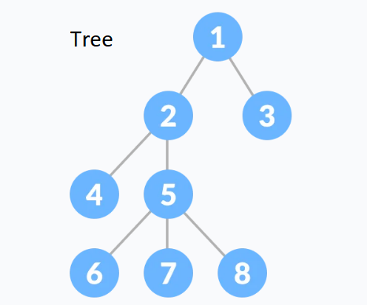

Структури даних, такі як масиви, пов’язані списки, черги, являють собою лінійні структури даних, у яких дані зберігаються послідовно. Щоб виконати будь-яку операцію в лінійній структурі даних, часова складність збільшується зі збільшенням обсягу даних. Що може бути неприйнятним.

Різні деревоподібні структури даних забезпечують більш швидкий та простий доступ до даних, оскільки це нелінійна структура даних.

Дерево складають **вузли та ребра**.

**Вузол** (Node) — об’єкт, який містить ключ або значення та покажчики на його дочірні вузли. Останні вузли кожного шляху називаються **листовими вузлами** або зовнішніми вузлами, які не містять посилання/покажчик на дочірні вузли.

Вузол, що має хоча б дочірній вузол, називається **внутрішнім вузлом**.

Вузол в бінарному дереві лише з одним дочірнім вузлом є **напіввузлом**.

**Ребро** (Edge) – зв’язок між будь-якими двома вузлами.

**Корінь** (Root) – найвищий вузол дерева.

**Ступінь вузла** (Degree of a Node) - кількість дочірніх вузлів.

**Висота вузла** (Height of a Node) - кількість ребер від вузла до найглибшого листа (тобто найдовший шлях від вузла до листового вузла).

**Глибина вузла** (Depth of a Node) – кількість ребер від кореня до вузла. Глибина вузла вказує на скільки рівнів вузол віддалений від кореня. Отже, корінь має глибину 0, нащадки кореня мають глибину 1 і так далі.

**Висота дерева** (Height of a Tree) - висота кореневого вузла чи глибина найглибшого вузла.

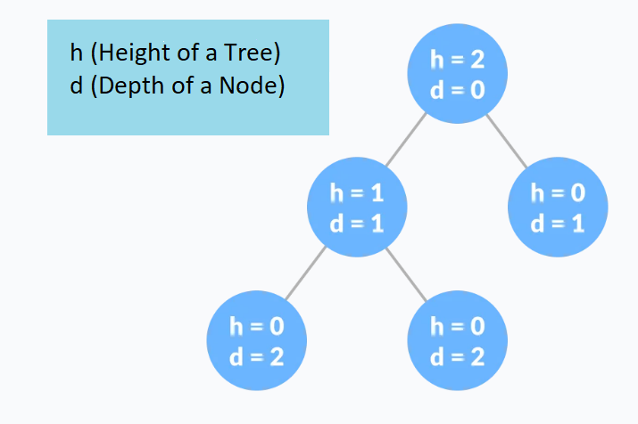

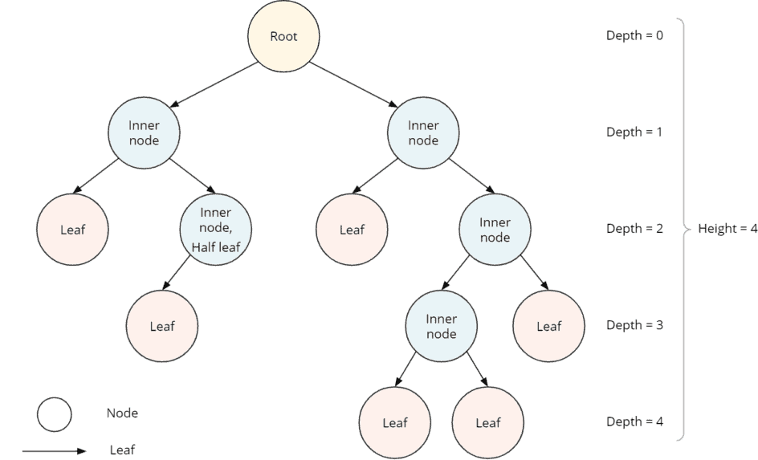

Дерево, яке зазвичай використовується в інформаційних технологіях, є **двійковим/бінарним деревом (binary tree)**.

**Бінарне дерево (binary tree)** складається з вузлів, які мають не більше 2 дочірніх елементів/вузлів. Дочірні вузли називаються лівим і правим дочірніми вузлами. Зазвичай використовується для: стиснення даних, зберігання файлів.

**Основні типи бінарних дерев.**

**Повне бінарне дерево** (Full Binary Tree). У повному бінарному дереві всі вузли або не мають дітей, або мають двох дітей.

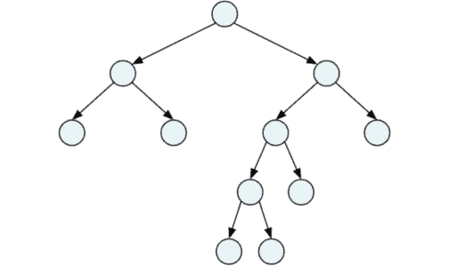

**Повне (Закінчене) бінарне дерево** (Complete Binary Tree). У повному (закінченному) бінарному дереві всі рівні, крім, можливо, останнього, повністю заповнені. Якщо останній рівень заповнений не повністю, то його вузли розташовуються максимально ліворуч.

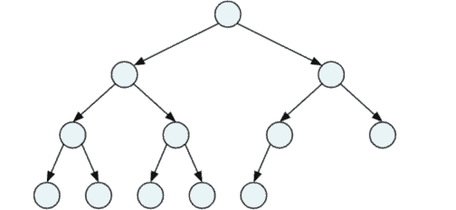

**Ідеальне бінарне дерево** (Perfect Binary Tree) — повне бінарне дерево, у якому всі листи мають однакову глибину. В ідеальному бінарному дереві кожен внутрішній вузол має рівно два дочірніх вузла, а всі листові вузли знаходяться на одному рівні.

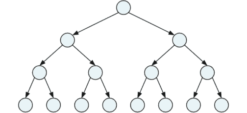

**Збалансоване бінарне дерево** (Balanced Binary Tree). У збалансованому бінарному дереві, яке також називають бінарним деревом із збалансованою висотою, ліве та праве піддерева кожного вузла відрізняються за висотою щонайбільше на одиницю.

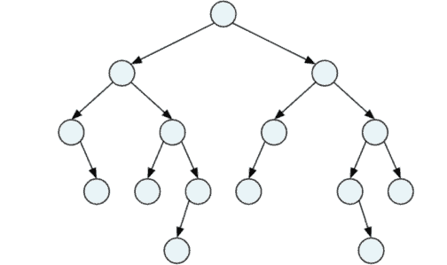

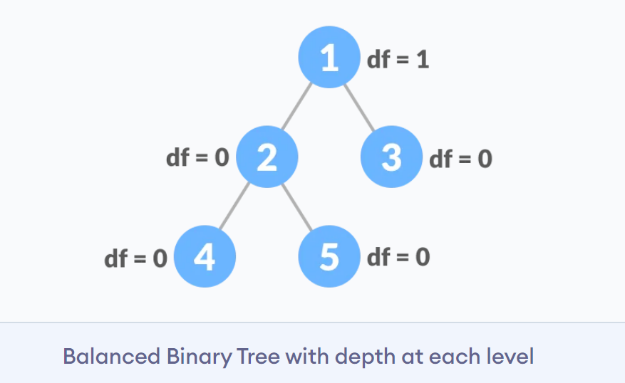

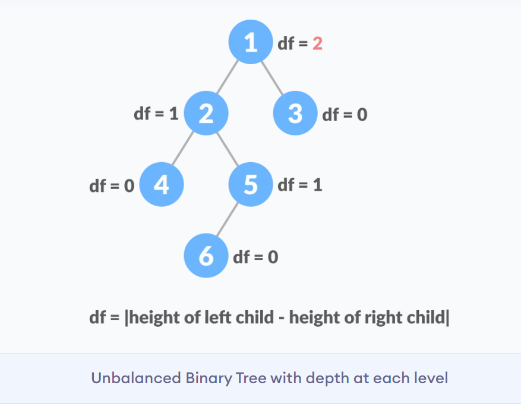